# team

Allegra Frickel

3/27/2019

```r
library(readxl)
defense <- read_excel('cyclonesFootball2018.xlsx', sheet='Defensive')
str(defense)
```

```
## Classes 'tbl_df', 'tbl' and 'data.frame':    446 obs. of  11 variables:
##  $ Name             : chr  "Eisworth, Greg" "Eisworth, Greg" "Eisworth, Greg" "Eisworth, Greg" ...
##  $ Opponent_Opponent: chr  "Iowa" "Oklahoma" "Akron" "TCU" ...
##  $ Tackles_Solo     : chr  "3" "6" "7" "6" ...
##  $ Tackles_ASST     : chr  "3" "8" "2" "3" ...
##  $ Tackles_TFL      : chr  "0" "1.0" "1.0" "0" ...
##  $ Tackles_Sack     : chr  "0" "0" "0" "0" ...
##  $ Turnover_FF      : chr  "0" "1" "0" "0" ...
##  $ Turnover_FR      : chr  "0" "0" "0" "0" ...
##  $ Turnover_INT     : chr  "0" "0" "0" "0" ...
##  $ Pass_QBH         : chr  "0" "0" "0" "0" ...
##  $ Pass_PB          : chr  "0" "0" "3" "0" ...
```

```r
offense <- read_excel('cyclonesFootball2018.xlsx', sheet='Offensive')
str(offense)
```

```
## Classes 'tbl_df', 'tbl' and 'data.frame':    168 obs. of  12 variables:
##  $ Name             : chr  "Jones, Deshaunte" "Jones, Deshaunte" "Jones, Deshaunte" "Jones, Deshaunte" ...
##  $ Opponent_Opponent: chr  "Iowa" "Oklahoma" "Akron" "TCU" ...
##  $ Receiving_REC    : chr  "1" "9" "6" "3" ...
##  $ Receiving_YDS    : chr  "31" "66" "39" "23" ...
##  $ Receiving_TD     : chr  "0" "0" "0" "0" ...
##  $ Rushing_ATT      : chr  NA NA NA NA ...
##  $ Rushing_YDS      : chr  NA NA NA NA ...
##  $ Rushing_TD       : chr  NA NA NA NA ...
##  $ Passing_CMP-ATT  : chr  NA NA NA NA ...
##  $ Passing_YDS      : chr  NA NA NA NA ...
##  $ Passing_TD       : chr  NA NA NA NA ...
##  $ Passing_INT      : chr  NA NA NA NA ...
```

```r
bio <- read_excel('cyclonesFootball2018.xlsx', sheet='Biography')
str(bio)
```

```
## Classes 'tbl_df', 'tbl' and 'data.frame':    123 obs. of  7 variables:
##  $ Name      : chr  "Akers, Landen" "Allen, Chase" "Alt, Gerry" "Anderson, Cole" ...
##  $ Position  : chr  "Wide Receiver" "Tight End" "Offensive Line" "Tight End" ...
##  $ Height    : chr  "6-0" "6-7" "6-2" "6-4" ...
##  $ Weight    : chr  "192" "240" "290" "250" ...
##  $ Class     : chr  "Redshirt Sophomore" "Redshirt Sophomore" "Redshirt Freshman" "Redshirt Senior" ...
##  $ Hometown  : chr  "Cedar Rapids, Iowa" "Nixa, Mo." "Cedar Rapids, Iowa" "League City, Texas" ...
##  $ Highschool: chr  "Washington" "Nixa" "Washington" "Clear Falls" ...
```

```r
library(tidyverse)
```

```r
library(dplyr)
library(ggplot2)
```

**Part One: Cleaning**

1. Player names and opponent names are factors

```r
defense$Name <- as.factor(defense$Name)
defense$Opponent_Opponent <- as.factor(defense$Opponent_Opponent)
offense$Name <- as.factor(offense$Name)
offense$Opponent_Opponent <- as.factor(offense$Opponent_Opponent)
bio$Name <- as.factor(bio$Name)
```

2. Offensive and defensive names statistics are numerical

```r
defense <- defense %>% mutate_if(is.character,as.numeric)
offense <- offense %>% mutate_if(is.character,as.numeric)
bio$Weight <- as.numeric(bio$Weight)
```

3. Change height to numeric

```r
bio <- bio %>% separate(Height, into = c("Feet", "Inches"), sep = "-")
```

```r
bio$Feet <- as.numeric(bio$Feet)
bio$Inches <- as.numeric(bio$Inches)
bio <- bio %>% mutate(HeightDec = Feet + Inches/12)
#would like to move HeightDec column after inches column
```

Print the structures of the Clean dataframes.

```r
defClean <- defense
offClean <- offense
bioClean <- bio
str(defClean)
```

```
## Classes 'tbl_df', 'tbl' and 'data.frame':    446 obs. of  11 variables:
##  $ Name             : Factor w/ 42 levels "Akers, Landen",..: 7 7 7 7 7 7 7 7 7 7 ...
##  $ Opponent_Opponent: Factor w/ 13 levels "Akron","Baylor",..: 4 7 1 9 8 13 11 5 2 10 ...
##  $ Tackles_Solo     : num  3 6 7 6 3 5 3 7 2 9 ...
##  $ Tackles_ASST     : num  3 8 2 3 0 3 2 1 4 3 ...
##  $ Tackles_TFL      : num  0 1 1 0 1 1 0 0 0 0 ...
##  $ Tackles_Sack     : num  0 0 0 0 0 1 0 0 0 0 ...
##  $ Turnover_FF      : num  0 1 0 0 0 0 0 0 0 1 ...
##  $ Turnover_FR      : num  0 0 0 0 0 0 0 0 0 0 ...
##  $ Turnover_INT     : num  0 0 0 0 0 0 1 0 0 0 ...
##  $ Pass_QBH         : num  0 0 0 0 0 0 0 0 0 0 ...
##  $ Pass_PB          : num  0 0 3 0 0 0 0 0 0 0 ...
```

```r
str(offClean)
```

```
## Classes 'tbl_df', 'tbl' and 'data.frame':    168 obs. of  12 variables:
##  $ Name             : Factor w/ 15 levels "Akers, Landen",..: 6 6 6 6 6 6 6 6 6 6 ...
##  $ Opponent_Opponent: Factor w/ 13 levels "Akron","Baylor",..: 4 7 1 9 8 13 11 5 2 10 ...
##  $ Receiving_REC    : num  1 9 6 3 6 1 1 4 4 0 ...
##  $ Receiving_YDS    : num  31 66 39 23 37 32 4 31 39 0 ...
##  $ Receiving_TD     : num  0 0 0 0 1 1 0 0 1 0 ...
##  $ Rushing_ATT      : num  NA NA NA NA NA NA NA NA NA NA ...
##  $ Rushing_YDS      : num  NA NA NA NA NA NA NA NA NA NA ...
##  $ Rushing_TD       : num  NA NA NA NA NA NA NA NA NA NA ...
##  $ Passing_CMP-ATT  : num  NA NA NA NA NA NA NA NA NA NA ...
##  $ Passing_YDS      : num  NA NA NA NA NA NA NA NA NA NA ...
##  $ Passing_TD       : num  NA NA NA NA NA NA NA NA NA NA ...
##  $ Passing_INT      : num  NA NA NA NA NA NA NA NA NA NA ...
```

```r
str(bioClean)
```

```
## Classes 'tbl_df', 'tbl' and 'data.frame':    123 obs. of  9 variables:
##  $ Name      : Factor w/ 123 levels "Akers, Landen",..: 1 2 3 4 5 6 7 8 9 10 ...
##  $ Position  : chr  "Wide Receiver" "Tight End" "Offensive Line" "Tight End" ...
##  $ Feet      : num  6 6 6 6 6 5 6 6 6 6 ...
##  $ Inches    : num  0 7 2 4 0 11 0 3 2 2 ...
##  $ Weight    : num  192 240 290 250 191 205 192 224 251 284 ...
##  $ Class     : chr  "Redshirt Sophomore" "Redshirt Sophomore" "Redshirt Freshman" "Redshirt Senior" ...
##  $ Hometown  : chr  "Cedar Rapids, Iowa" "Nixa, Mo." "Cedar Rapids, Iowa" "League City, Texas" ...
##  $ Highschool: chr  "Washington" "Nixa" "Washington" "Clear Falls" ...
##  $ HeightDec : num  6 6.58 6.17 6.33 6 ...
```

**Part Two: Tidying (1)**

1. Reformat defClean into a tidy format using gather. The type of statistic is added as a new key column names Statistic.

```r
defClean <- defClean %>% gather(key = Statistic, value = Count, 3:11)
```

2. Create a histogram for each defensive statistic. Use facet_wrap to draw all histograms in a single plot. What defensive skills are rare?

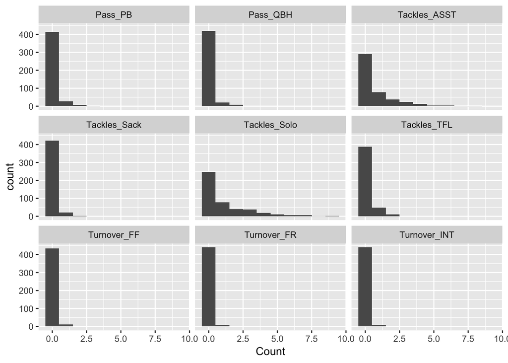

```r
ggplot(defClean, aes(x=Count)) + geom_histogram(binwidth = 1) + facet_wrap(~Statistic)
```

Based on the histrograms above, Turnover_FR (fumble recovery) and Turnover_INT (turnover interception) skills are rare.

Based on the histrograms above, Turnover_FR and Turnover_INT skills are rare.

3. Did ISU have better defense against West Virginia or KState? Create a scatterplot with the x-axis being the number of solo tackles against West Virginia. The y-axis should be against KState. A large number of solo tackles indicates a good defense.

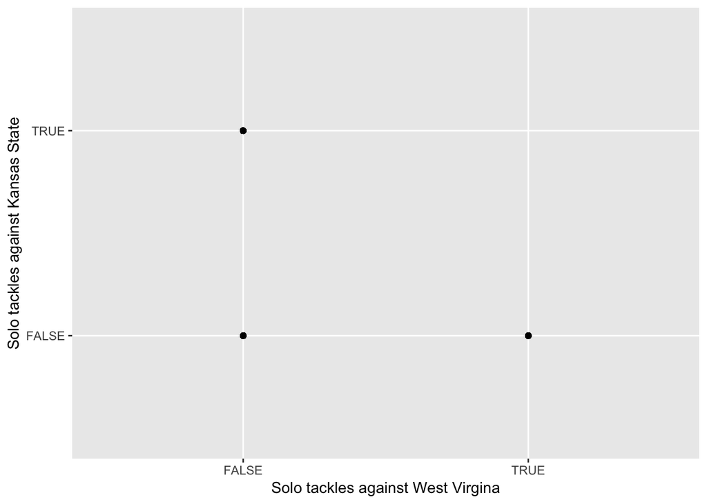

```r
plt <- ggplot(defClean, aes(x= Opponent_Opponent == 'West Virginia', y= Opponent_Opponent == 'Kansas State')) + geom_point() + xlab('Solo tackles against West Virgina') + ylab('Solo tackles against Kansas State')
plt
```

**Part Two: Tidying (2)**

1. Separate the Hometown column into two columns, name the city and the state. Print the first few rows of these two columns.

```r
bioClean <- bioClean %>% separate(Hometown, into = c("City", "State"), sep = ",")
head(bioClean)
```

```
## # A tibble: 6 x 10
##   Name  Position  Feet Inches Weight Class City  State Highschool HeightDec
##   <fct> <chr>    <dbl>  <dbl>  <dbl> <chr> <chr> <chr> <chr>          <dbl>
## 1 Aker… Wide Re…     6      0    192 Reds… Ceda… " Io… Washington      6
## 2 Alle… Tight E…     6      7    240 Reds… Nixa  " Mo… Nixa            6.58
## 3 Alt,… Offensi…     6      2    290 Reds… Ceda… " Io… Washington      6.17
## 4 Ande… Tight E…     6      4    250 Reds… Leag… " Te… Clear Fal…      6.33
## 5 Assa… Placeki…     6      0    191 Reds… Nape… " Il… Central         6
## 6 Aust… Linebac…     5     11    205 Reds… Waln… " Ca… Bishop Am…      5.92
```

2. How many players are there from each state?

```r
table(bioClean$State)
```

```
##
##      Ariz.       Ark.  Australia     Calif.       D.C.       Fla.
##          3          2          2          8          1          8
##        Ga.       Ill.       Iowa       Kan.      Mass.        Md.
##          2          5         44          3          1          1
##      Mich.      Minn.      Miss.        Mo.       Neb.    Nigeria
##          5          2          1          1          1          1
##       Ohio      Okla.        Pa.       S.C.      Texas        Va.
##         10          4          2          2          9          1
##       Wis.
##          4
```

**Part Three: Joining data frames**

1. Find where the offensive players come from by joining the offensive data and player biography data appropriately.

```r
anti_join(bioClean, offClean, by = "Name")
```

```
## # A tibble: 109 x 10
##    Name  Position  Feet Inches Weight Class City  State Highschool
##    <fct> <chr>    <dbl>  <dbl>  <dbl> <chr> <chr> <chr> <chr>
##  1 Alt,… Offensi…     6      2    290 Reds… Ceda… " Io… Washington
##  2 Ande… Tight E…     6      4    250 Reds… Leag… " Te… Clear Fal…
##  3 Assa… Placeki…     6      0    191 Reds… Nape… " Il… Central
##  4 Aust… Linebac…     5     11    205 Reds… Waln… " Ca… Bishop Am…
##  5 Azun… Defensi…     6      0    192 Reds… Gran… " Te… Lake Ridge
##  6 Bail… Defensi…     6      3    224 Reds… Clar… " Mi… Clarksdale
##  7 Bail… Defensi…     6      2    251 Juni… Jack… " Fl… Raines
##  8 Bail… Defensi…     6      2    284 Reds… Jack… " Fl… Raines
##  9 Bart… Tight E…     6      4    242 Fres… Gret… " Ne… Gretna
## 10 Bent… Defensi…     6      2    256 Reds… Van … " Io… Van Meter
## # … with 99 more rows, and 1 more variable: HeightDec <dbl>
```

2. Is there a relationship between the weight of the player and the receiving yards (Receiving_YDS)?

```r
df <- inner_join(bioClean, offClean, by = "Name")
```

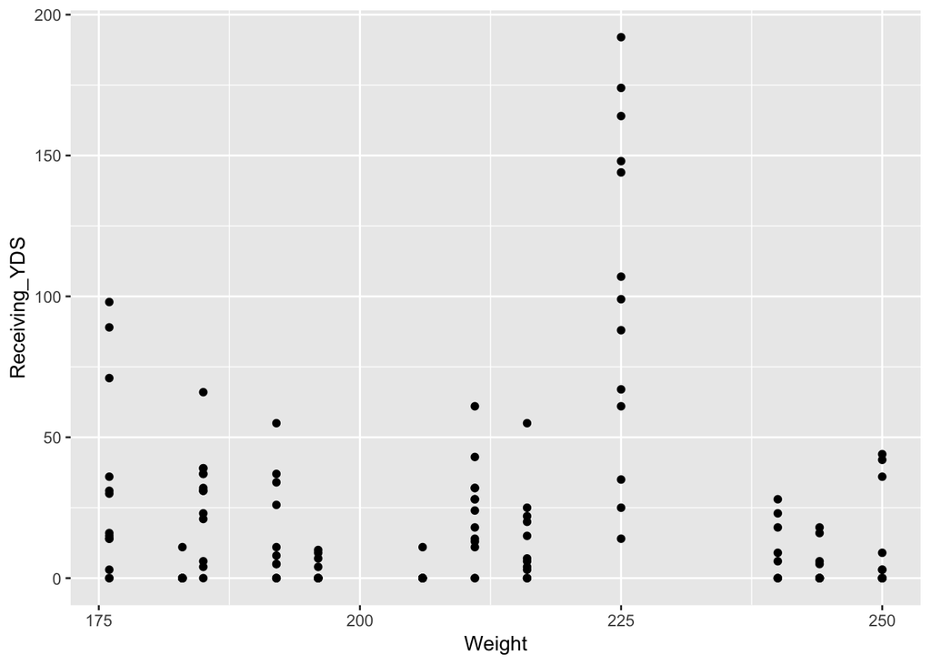

```r
ggplot(df, aes(x=Weight, y=Receiving_YDS)) + geom_point()
```

There may not be a relationship between receiving yards and weight, but this graph displays that those who are 225 pounds had the most receiving yards.

3. Is there a relationship between weight and solo tackles?

```r
df1 <- inner_join(bioClean, defClean, by = "Name")
```

```r
#ggplot(df1, aes(x=Weight, y=Tackles_Solo)) + geom_point()
```